# Probabilités et statistiques pour informaticiens

# Série 1)

# 1) Dénombrabilité

a)

```python
def pad(p, n): #Pad adds zeros in front of bin number for formatting.
    return '0'*(p - len(n)) + n

#Works by computing {0,1...2^i} for i changing as much as required, then concatenates all arrays.
def calcTable(n):
    if n == 0: return 0 #Nothing to do here.
    arr = []
    m = len(bin(n)[2:]) #m is the amount of characters required to write the input in binary.
    for i in range(0, m+1): #i is the current length of words in sub array.
        for k in range(0, 2**i): #k calculates every value from 0 to 2^i.
            arr += [pad(i, bin(k)[2:])] #we concatenate every value using correct padding.
    arr.pop(0) #I don't want to have two zeroes at the start.
    return arr #I return array, but you can return arr[n] for said value.

print(calcTable(10)) #NB: I know this is not the most efficient way of doing this.
```

```
['0', '1', '00', '01', '10', '11', '000', '001', '010', '011', '100', '101', '110', '111', '0000', '0001', '0010', '0011', '0100', '0101', '0110', '0111', '1000', '1001', '1010', '1011', '1100', '1101', '1110', '1111']
```

b)

By writing $N \times N$ as a table of values, I find the algorithm is as follows :

*1) Place yourself on the correct diagonal.*

*2) Advance as much as necessary on said diagonal.*

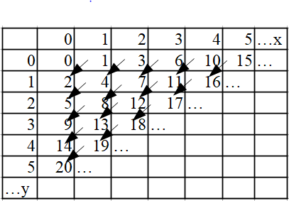

This is done with the following equations, (which I learnt from Samuel Simko after much trial and error)

$x := max \{x | \sum_{i = 0}^x i = \frac{x(x+1)}{2} \leq n \} $

$\lambda = n - \frac{x(x+1)}{2} $ with $ b(n) := (x - \lambda, \lambda)$

Here's the logic behind this equation, say $n = 12, b(n) = (2,2)$ according to the table, but how do we calculate it ? Well we need to get on the right diagonal, which in this case starts at $x = 10$, and what we notice is that the second line follows the sequence : $0, 1, 3, 6, 10, 15$ we first add one, then two, then 3 then 4, it's a good old sum of increasing integers. So if we want to find the index corresponding to the beggining of the diagonal, we must look for the maximum of $\sum_{i=0}^x i \leq n$ this explains the choice of $x$.

With this choice of x, $\frac{x(x+1)}{2}$ will give us the index of the start of the diagonal. Once $x$ is obtained, we must go down the diagonal (or up depending on how you draw the table) until we reach the correct index, $n$. To do this, we must realise that we will go down by $ \lambda := n - \frac{x(x+1)}{2}$ diagonally. When going down the diagonal, $x(n)$ is decreased by lambda, but $y(n)$ is increased by lambda. Which explains why $x(n) = x - \lambda$ and $y(n) = \lambda$.

The code that calculates this follows.

```python
def findX(n):
    for i in range(1,n):
        if n - (i*(i+1))/2 < 0:
            return i-1

def calcNCrossN(n):
    x = findX(n)
    lamb = n - (x*(x+1))/2
    return (x - lamb, lamb)


print(calcNCrossN(34))
```

```
(1.0, 6.0)
```

Exercice 2,3,4) Théorie des ensembles et mesure de probabilité

NB : Je rends les réponses au papier, car il n'y a pas de code demandé.

[figure not shown]